# **Loan Default Prediction**

# **1.0 Introduction**

## **1.1 Context**

A major proportion of retail bank profit comes from interests in the form of home loans. These loans are borrowed by regular income/high-earning customers. Banks are most fearful of defaulters, as bad loans (NPA) usually eat up a major chunk of their profits. Therefore, it is important for banks to be judicious while approving loans for their customer base. The approval process for the loans is multifaceted. Through this process, the bank tries to check the creditworthiness of the applicant on the basis of a manual study of various aspects of the application. The entire process is not only effort-intensive but also prone to wrong judgment/approval owing to human error and biases. There have been attempts by many banks to automate this process by using heuristics. But with the advent of data science and machine learning, the focus has shifted to building machines learning models that can learn this approval process and make it free of biases and more efficient. At the same time, one important thing to keep in mind is to make sure that the machine does not learn the biases that previously crept in because of the human approval process.

## **1.2 Problem Statement**

A bank's consumer credit department aims to simplify the decision-making process for home equity lines of credit to be accepted. To do this, they will adopt the Equal Credit Opportunity Act's guidelines to establish an empirically derived and statistically sound model for credit scoring. The model will be based on the data obtained via the existing loan underwriting process from recent applicants who have been given credit. The model will be built from predictive modeling techniques, but the model created must be interpretable enough to provide a justification for any adverse behavior (rejections).

## **1.3 Objective**

Build a classification model to predict clients who are likely to default on their loan and give recommendations to the bank on the important features to consider while approving a loan. Proprietary content.

## **1.4 Need of the present study**

The need for this study is multifaceted, addressing critical issues related to risk management, profitability, efficiency, and regulatory compliance within the bank's credit department.

Here is a breakdown of the necessity of building an automated loan default prediction models:

a) The resultant models accurately predict which applicants are most likely to default, therefore minimizing non-performing loans.. Bad loans (Non-Performing Assets) directly erode a bank's capital and profits.

b) Maximizing Profitability: By reducing defaults, the bank protects the income earned from the majority of reliable customers, leading to a more stable and higher profit margin.

c) Judicious Lending: The study ensures that the bank is making decisions based on empirical evidence and statistical soundness, rather than guesswork, reducing overall financial risk exposure.

d) An automated model allows the bank to process a much larger volume of loan applications quickly, supporting business growth without scaling up the manual workforce proportionally.

e) Automated, instant credit scoring significantly reduces the time from application to approval, improving the customer experience and giving the bank a competitive advantage.

f) The manual process is prone to wrong judgment/approval owing to human error and biases." A properly constructed machine learning model can apply the same objective criteria to every application, making the process fairer and more consistent.

g) Since the models are built to avoid Learning Historical Biases that existed in the historical (human-approved) data.

h) The models are built to be interpretable enough to provide clear, legal justification for any rejection. This ensures that every loan application rejection is clearly explained.

## **1.5 Business/social opportunities**

This study presents significant opportunities across both the bank's core business operations and its broader social and ethical impact. The opportunities include:

### **Business Opportunities**

a) The study provides the bank with a powerful competitive advantage and enhanced financial performance. It culminates into a model that allows the bank to precisely quantify the risk of each applicant. This enables sophisticated pricing—offering lower interest rates to low-risk customers and higher, risk-adjusted rates to moderate-risk customers, maximizing total returns.

b) By maintaining a lower default rate, the bank requires less capital set aside to cover potential losses (regulatory capital reserves), freeing up resources for other profitable ventures.

c) Identifying /isolating the features that are highly predictive of non-default allows the bank to focus its marketing efforts on customer segments that are statistically most likely to be high-performing, reliable borrowers.

d) Automating the underwriting process drastically reduces the operational costs associated with manual review, data collection, and human-based decision-making.

e) Near-instantaneous credit decisions improve customer experience, leading to higher conversion rates for applications and potentially attracting more prime borrowers.

f) The model standardizes the credit approval process, ensuring all branches and loan officers adhere to the same objective criteria, reducing internal errors and inconsistent judgments.

g) By identifying high-risk borrowers before they default, the bank can implement early intervention strategies (e.g., offering loan restructuring, financial counseling, or short-term relief) to prevent the loss, which is always cheaper than recovering from a default.

h) The model data can be integrated to predict the long-term value and loyalty of a customer, informing decisions on cross-selling other high-value banking products (e.g., investment accounts, insurance).

### **Social and Ethical Opportunities**

a) By consciously building and auditing the model to meet ECOA guidelines, the bank actively reduces the influence of unconscious human biases (which may relate to protected characteristics) in lending decisions. This leads to fairer outcomes.

b) An objective, statistically driven model can safely extend credit to underserved populations whose creditworthiness might have been overlooked or misjudged by rigid, traditional manual rules, thereby promoting economic mobility.

c) The models allow the bank to provide clear, actionable reasons for rejections. This transparency builds trust with applicants, even those who are rejected, and ensures robust compliance with fair lending laws.

d) The rejection justification can educate the applicant on specific financial factors (e.g., high debt-to-income ratio or utilization rate) they need to improve to qualify in the future, providing a path toward financial health.

e) By improving the quality of its loan portfolio, the bank contributes to the overall stability of the financial system. Responsible lending practices, enabled by predictive models, help mitigate the kind of excessive risk-taking that can lead to broader financial crises.

# **2.0 Data Report**

## **Data Dictionary**

The Home Equity dataset (HMEQ) contains baseline and loan performance information for recent home equity loans. The target (BAD) is a binary variable that indicates whether an applicant has ultimately defaulted or has been severely delinquent. There are 12 input variables registered for each applicant.

● BAD: 1 = Client defaulted on loan, 0 = loan repaid

● LOAN: Amount of loan approved

● MORTDUE: Amount due on the existing mortgage

● VALUE: Current value of the property

● REASON: Reason for the loan request (HomeImp = home improvement, DebtCon= debt consolidation which means taking out a new loan to pay off other liabilities and consumer debts)

● JOB: The type of job that loan applicant has such as manager, self, etc.

● YOJ: Years at present job

● DEROG: Number of major derogatory reports (which indicates serious delinquency or late payments).

● DELINQ: Number of delinquent credit lines (a line of credit becomes delinquent when a borrower does not make the minimum required payments 30 to 60 days past the day on which the payments were due)

● CLAGE: Age of the oldest credit line in months

● NINQ: Number of recent credit inquiries

● CLNO: Number of existing credit lines

● DEBTINC: Debt-to-income ratio (all monthly debt payments divided by gross monthly income. This number is one of the ways lenders measure a borrower’s ability to manage the monthly payments to repay the money they plan to borrow)

## **2.1 Understand the data collection methodology**

The data collection methodology for this loan default prediction study must focus on gathering comprehensive, accurate, and relevant historical data that reflects the outcomes of past lending decisions. The structured methodology for data collection includes the following:

### **Define the Data Scope and Sources**

The primary goal is to collect data that encompasses the entire lifecycle of a loan application, from initial application to final outcome (payment or default).

### **Time Window Definition:**

a) Data should span a sufficient historical period (e.g., 5 to 7 years) to capture different economic cycles (recessions, booms) and ensure a representative sample of defaults.

b) A decision has to be made on how long a loan must be active for the default status to be considered final. For home equity loans, this window is typically long (e.g., 24-36 months post-origination) to ensure a meaningful outcome has been observed.

c) Only loans that have had enough time to either default or become reliably current/paid off should be included in the dataset. Loans originated too recently must be excluded (right-censoring).

### **Data Extraction and Integration**

a) Data is pulled from various source systems (LOS, servicing, credit bureau archives) into raw files (e.g., SQL exports, CSVs).

b) Use a unique identifier is defined (e.g., Application_ID or Loan_ID) to link all disparate records for a single applicant/loan across various systems.

c) Features with the same meaning MUST have consistent formats and definitions across all extracted sources (e.g., making sure 'income' is always annualized and in the same currency unit).

d) Finally, all relevant features are merged together with the target variable into a single, comprehensive table suitable for machine learning training.

### **Addressing Data Biases (Sampling).**

This step is critical for model quality and fairness.

a)The model will primarily learn from data on applicants who were approved by the human underwriters. To understand the true risk profile of the entire applicant population, the loaning organisation must ideally include a sample of rejected applications and infer their hypothetical default outcome (using statistical methods like propensity score matching, if feasible, although this is advanced). If only approved loans are used, the model will suffer from sample selection bias.

b) Since the defaults are rare, the collected data will be highly imbalanced. The methodology should include the explicit plan to address this during the subsequent data preparation phase (e.g., Oversampling, Undersampling, or weight adjustment).

### **Data Privacy and Governance**

a) Before the commencement of analysis, directly identifiable information (names, addresses, account numbers) must be removed or masked to comply with internal privacy policies and external regulations.

## **2.2 Comment on how the data might have been collected**

The data for this loan default prediction study would have been collected primarily through an integration of internal banking systems and external credit bureaus. This was achieved following a structured process to create a comprehensive historical record. Here is a description of the probable sources of the data and how it was consolidated.

### **Internal Data Sources:**

The financial organization would pull data from its core operational systems, linking records by a unique applicant or loan ID. These systems include:

a) The Loan Origination System (LOS). This system holds all the information provided by the applicant at the time of application, including Stated income, employment history (duration, status), asset and reserve information, and the computed Debt-to-Income (DTI) ratio. Other information in this system are the requested loan amount, term length, purpose, and the underwriter's final decision (Approved/Rejected) and the date of the decision.

b) Loan Servicing System, Once the loan is approved and funded, this system tracks its performance over time. This system stores information including payment history, date of first delinquency, cure status, and the eventual binary outcome (Default/Charge-off vs. Paid/Current). It also maintains the collateral details including the appraised value of the home and the calculated Loan-to-Value (LTV) ratio. The Loan servicing system is the crucial source for the Target Variable.

### **External Data Sources**

External data, typically collected under strict authorization at the time of the application, provides a standardized view of the applicant's creditworthiness.

These sources include the Credit Bureau Reportswhich is the source of Credit Score, Credit History, Credit Utilization Rate and Delinquencies.

### **Data Integration and Sampling**

The most critical part of the collection is integrating these disparate data points into a single, usable dataset. The objective of this exercise is to consolidate all parts of the data into a single Analytical Base Table (ABT) CreationTime Synchronization:

Features must be captured as they existed at the time of the application, while the target variable (Default Status) is captured after a sufficient observation period (e.g., 24-36 months post-origination).

Finally the financial organization addresses the Sample Selection Bias and Ethical Feature Exclusion, Before being used for modeling.

## **2.3 Overview of data**

Here is a structured overview of the dataset:

a) The dataset contains 5,960 records and 13 features that are typical for a credit risk modeling exercise. The features can be categorized into the target variable, loan information, and applicant credit metrics.

b) The goal of the study is to predict column - BAD

c) The features that describe the requested loan and the collateral property are LOAN, MORTDUE, VALUE, REASON, JOB and YOJ

d) These variables that are crucial predictors of default are DEBTINC, DEROG, DELINQ, CLAGE, NINQ and CLNO.

**e) Key Data Challenges**

The primary challenge in the data preparation phase will be handling the significant volume of missing values which include the following.

i. DEBTINC is a cornerstone of credit scoring, and over 21% of the records are missing this value. Careful imputation or feature engineering is essential.

ii. MORTDUE and YOJ also have a substantial number of missing entries ($\sim8\%$ to $9.5\%$).

iii. The categorical features, REASON and JOB, will need proper encoding (e.g., One-Hot Encoding) before modeling.

## **2.4 Check the rows, columns, variable info, and descriptive details**

```python
# Libraries to help with reading and manipulating data
import pandas as pd
import numpy as np

# Libaries to help with data visualization
import matplotlib.pyplot as plt
import seaborn as sns

# To tune model, get different metric scores, and split data
from sklearn.metrics import (
    f1_score,
    accuracy_score,
    recall_score,
    precision_score,
    confusion_matrix,
    roc_auc_score,
    ConfusionMatrixDisplay,
)
from sklearn import metrics

from sklearn.model_selection import train_test_split, StratifiedKFold, cross_val_score

# To be used for data scaling and one hot encoding
from sklearn.preprocessing import StandardScaler, MinMaxScaler, OneHotEncoder

# To impute missing values
from sklearn.impute import SimpleImputer

# To oversample and undersample data
from imblearn.over_sampling import SMOTE
from imblearn.under_sampling import RandomUnderSampler

# To do hyperparameter tuning
from sklearn.model_selection import RandomizedSearchCV

# To be used for creating pipelines and personalizing them
from sklearn.pipeline import Pipeline
from sklearn.compose import ColumnTransformer

# To define maximum number of columns to be displayed in a dataframe
pd.set_option("display.max_columns", None)
pd.set_option("display.max_rows", None)

# To supress scientific notations for a dataframe
pd.set_option("display.float_format", lambda x: "%.3f" % x)

# To help with model building
from sklearn.linear_model import LogisticRegression
from sklearn.tree import DecisionTreeClassifier
from sklearn.ensemble import (
    AdaBoostClassifier,
    GradientBoostingClassifier,
    RandomForestClassifier,
    BaggingClassifier,
)
from xgboost import XGBClassifier

# To suppress scientific notations
pd.set_option("display.float_format", lambda x: "%.3f" % x)

# To suppress warnings
import warnings

warnings.filterwarnings("ignore")
```

## **2.4.1 Loading the dataset**

```python
#Read the Loan Default.csv
df_Loan = pd.read_csv('Loan Default.csv')
```

```python
#Keep a copy of the original dataframe before transformation for use in EDA
df_Loan_original = df_Loan.copy()
```

```python
#Show the first 5 rows of data
df_Loan.head()
```

|  | BAD | LOAN | MORTDUE | VALUE | REASON | JOB | YOJ | DEROG | DELINQ | CLAGE | NINQ | CLNO | DEBTINC |
| --- | --- | --- | --- | --- | --- | --- | --- | --- | --- | --- | --- | --- | --- |
| 0 | 1 | 1100 | 25860.000 | 39025.000 | HomeImp | Other | 10.500 | 0.000 | 0.000 | 94.367 | 1.000 | 9.000 | NaN |
| 1 | 1 | 1300 | 70053.000 | 68400.000 | HomeImp | Other | 7.000 | 0.000 | 2.000 | 121.833 | 0.000 | 14.000 | NaN |
| 2 | 1 | 1500 | 13500.000 | 16700.000 | HomeImp | Other | 4.000 | 0.000 | 0.000 | 149.467 | 1.000 | 10.000 | NaN |
| 3 | 1 | 1500 | NaN | NaN | NaN | NaN | NaN | NaN | NaN | NaN | NaN | NaN | NaN |
| 4 | 0 | 1700 | 97800.000 | 112000.000 | HomeImp | Office | 3.000 | 0.000 | 0.000 | 93.333 | 0.000 | 14.000 | NaN |

```python
#Displaying the last 5 rows of the data
df_Loan.tail()
```

|  | BAD | LOAN | MORTDUE | VALUE | REASON | JOB | YOJ | DEROG | DELINQ | CLAGE | NINQ | CLNO | DEBTINC |
| --- | --- | --- | --- | --- | --- | --- | --- | --- | --- | --- | --- | --- | --- |
| 5955 | 0 | 88900 | 57264.000 | 90185.000 | DebtCon | Other | 16.000 | 0.000 | 0.000 | 221.809 | 0.000 | 16.000 | 36.112 |
| 5956 | 0 | 89000 | 54576.000 | 92937.000 | DebtCon | Other | 16.000 | 0.000 | 0.000 | 208.692 | 0.000 | 15.000 | 35.860 |
| 5957 | 0 | 89200 | 54045.000 | 92924.000 | DebtCon | Other | 15.000 | 0.000 | 0.000 | 212.280 | 0.000 | 15.000 | 35.557 |
| 5958 | 0 | 89800 | 50370.000 | 91861.000 | DebtCon | Other | 14.000 | 0.000 | 0.000 | 213.893 | 0.000 | 16.000 | 34.341 |
| 5959 | 0 | 89900 | 48811.000 | 88934.000 | DebtCon | Other | 15.000 | 0.000 | 0.000 | 219.601 | 0.000 | 16.000 | 34.572 |

```python
#Showing the shape of the data
# Code to check the number of rows
# Using len()

print(f"Total rows: {df_Loan.shape[0]}")
print(f"Total columns: {df_Loan.shape[1]}")
# Printing the full shape tuple (rows, columns) for context
print(f"Full DataFrame shape (Rows, Columns): {df_Loan.shape}")
```

```
Total rows: 5960
Total columns: 13
Full DataFrame shape (Rows, Columns): (5960, 13)
```

The data has 5960 rows/ records and 13 columns

```python
# Code to check the variable info
print("--- Variable Information (Data Types and Missing Counts) ---")
df_Loan.info()
```

```
--- Variable Information (Data Types and Missing Counts) ---
<class 'pandas.core.frame.DataFrame'>
RangeIndex: 5960 entries, 0 to 5959
Data columns (total 13 columns):
 #   Column   Non-Null Count  Dtype
---  ------   --------------  -----
 0   BAD      5960 non-null   int64
 1   LOAN     5960 non-null   int64
 2   MORTDUE  5442 non-null   float64
 3   VALUE    5848 non-null   float64
 4   REASON   5708 non-null   object
 5   JOB      5681 non-null   object
 6   YOJ      5445 non-null   float64
 7   DEROG    5252 non-null   float64
 8   DELINQ   5380 non-null   float64
 9   CLAGE    5652 non-null   float64
 10  NINQ     5450 non-null   float64
 11  CLNO     5738 non-null   float64
 12  DEBTINC  4693 non-null   float64
dtypes: float64(9), int64(2), object(2)
memory usage: 605.4+ KB
```

```python
null_counts = df_Loan.isnull().sum()
total_rows = len(df_Loan)
null_percentages = (null_counts / total_rows) * 100

missing_data_report = pd.DataFrame({
    'Null Count': null_counts,
    'Null Percentage': null_percentages.round(2)
})

missing_data_report = missing_data_report[missing_data_report['Null Count'] > 0].sort_values(
    by='Null Count', ascending=False
)

print("--- Missing Value Report ---")
print(missing_data_report.to_markdown(numalign="left", stralign="left"))
```

```
--- Missing Value Report ---
|         | Null Count   | Null Percentage   |
|:--------|:-------------|:------------------|
| DEBTINC | 1267         | 21.26             |
| DEROG   | 708          | 11.88             |
| DELINQ  | 580          | 9.73              |
| MORTDUE | 518          | 8.69              |
| YOJ     | 515          | 8.64              |
| NINQ    | 510          | 8.56              |
| CLAGE   | 308          | 5.17              |
| JOB     | 279          | 4.68              |
| REASON  | 252          | 4.23              |
| CLNO    | 222          | 3.72              |
| VALUE   | 112          | 1.88              |
```

```python
#Checking Duplicate Records
print(f"Number of duplicate rows: {df_Loan.duplicated().sum()}")
```

```
Number of duplicate rows: 0
```

```python
# 1. Descriptive statistics for Numerical columns
print("--- 1. Descriptive Statistics (Numerical Variables) ---")
print(df_Loan.describe().T.to_markdown(numalign="left", stralign="left"))
print("\n")

# 2. Descriptive statistics for Categorical (object) columns
print("--- 2. Descriptive Statistics (Categorical Variables) ---")
print(df_Loan.describe(include='object').T.to_markdown(numalign="left", stralign="left"))
print("\n")

# 3. Key Finding: Class Distribution of the Target Variable 'BAD'
print("--- 3. Key Finding: Target Variable (BAD) Class Distribution ---")
bad_counts = df_Loan['BAD'].value_counts()
bad_percentages = df_Loan['BAD'].value_counts(normalize=True) * 100

bad_report = pd.DataFrame({
    'Count': bad_counts,
    'Percentage': bad_percentages.round(2)
})
print(bad_report.to_markdown(numalign="left", stralign="left"))
```

```
--- 1. Descriptive Statistics (Numerical Variables) ---
|         | count   | mean     | std      | min      | 25%     | 50%     | 75%     | max     |
|:--------|:--------|:---------|:---------|:---------|:--------|:--------|:--------|:--------|
| BAD     | 5960    | 0.199497 | 0.399656 | 0        | 0       | 0       | 0       | 1       |
| LOAN    | 5960    | 18608    | 11207.5  | 1100     | 11100   | 16300   | 23300   | 89900   |
| MORTDUE | 5442    | 73760.8  | 44457.6  | 2063     | 46276   | 65019   | 91488   | 399550  |
| VALUE   | 5848    | 101776   | 57385.8  | 8000     | 66075.5 | 89235.5 | 119824  | 855909  |
| YOJ     | 5445    | 8.92227  | 7.57398  | 0        | 3       | 7       | 13      | 41      |
| DEROG   | 5252    | 0.25457  | 0.846047 | 0        | 0       | 0       | 0       | 10      |
| DELINQ  | 5380    | 0.449442 | 1.12727  | 0        | 0       | 0       | 0       | 15      |
| CLAGE   | 5652    | 179.766  | 85.8101  | 0        | 115.117 | 173.467 | 231.562 | 1168.23 |
| NINQ    | 5450    | 1.18606  | 1.72867  | 0        | 0       | 1       | 2       | 17      |
| CLNO    | 5738    | 21.2961  | 10.1389  | 0        | 15      | 20      | 26      | 71      |
| DEBTINC | 4693    | 33.7799  | 8.60175  | 0.524499 | 29.14   | 34.8183 | 39.0031 | 203.312 |


--- 2. Descriptive Statistics (Categorical Variables) ---
|        | count   | unique   | top     | freq   |
|:-------|:--------|:---------|:--------|:-------|
| REASON | 5708    | 2        | DebtCon | 3928   |
| JOB    | 5681    | 6        | Other   | 2388   |


--- 3. Key Finding: Target Variable (BAD) Class Distribution ---
| BAD   | Count   | Percentage   |
|:------|:--------|:-------------|
| 0     | 4771    | 80.05        |
| 1     | 1189    | 19.95        |
```

```python
print("--- Unique Values for Categorical Variables ---")
categorical_cols = df_Loan.select_dtypes(include='object').columns

for col in categorical_cols:
    print(f"\nFeature: {col}")
    print(df_Loan[col].value_counts().to_markdown(numalign="left", stralign="left"))
```

```
--- Unique Values for Categorical Variables ---

Feature: REASON
| REASON   | count   |
|:---------|:--------|
| DebtCon  | 3928    |
| HomeImp  | 1780    |

Feature: JOB
| JOB     | count   |
|:--------|:--------|
| Other   | 2388    |
| ProfExe | 1276    |
| Office  | 948     |
| Mgr     | 767     |
| Self    | 193     |
| Sales   | 109     |
```

### **Findings:**

a) Total Entries: 5,960

b) Data Types: 9 columns are float (float64), 2 are integer (int64), and 2 are string/object (object).

c) Missing Values: All columns except BAD (Target) and LOAN (Loan Amount) have missing values, which will need to be addressed during data cleaning. The DEBTINC column has the highest number of missing values (only 4,693 non-null out of 5,960).

d) The DEBTINC (Debt-to-Income Ratio) feature is missing in over 21% of the records, which is a major issue as this is a highly critical variable in credit risk modeling. All other variables have less than $12\%$ missing data.

e) High Class Imbalance: The most critical finding is the significant class imbalance in the target variable BAD. Approximately 80% of the loans are "Good" (0), while only 20% are "Bad" (1). This ratio requires special attention during model training (e.g., using stratified sampling, oversampling, or weighted loss functions) to ensure the model accurately predicts the minority (default) class.

f) High Missingness in Critical Feature: The DEBTINC (Debt-to-Income ratio) is a vital metric in lending but is missing in over 21% of the data, which must be carefully addressed through imputation.

g) Loan Purpose Dominance: The primary purpose of the loans in the dataset is overwhelmingly DebtCon (Debt Consolidation), which accounts for roughly $69\%$ of the non-missing loan reasons. This suggests the model will be learning the risk profiles primarily associated with debt consolidation loans.

h) Credit Metrics Outliers: The maximum values for DELINQ (15) and DEROG (10) are substantially higher than the 75th percentile (0 for both), indicating that while most applicants have very clean credit, a small set has seriously impaired credit history, which may influence model robustness.

### **Categorical Variables**

a) REASON (Loan Purpose):

The data is heavily skewed towards Debt Consolidation (DebtCon) loans, which account for 3,928 out of 5,708 non-missing values. The remaining loans are for Home Improvement (HomeImp), totaling 1,780. This confirms that the model will be primarily trained on the risk characteristics of applicants seeking to consolidate debt.

b) JOB (Occupation):

The most frequent job category is Other ($\mathbf{2,388}$), which is a broad category and may need further investigation or encoding strategies. The remaining major categories are ProfExe (Professional/Executive), Office, and Mgr (Manager). The categories Self (Self-Employed) and Sales are relatively small in number, especially Sales with only 109 entries. These small groups may pose challenges for robust statistical analysis.

# **3.0 Data Preprocessing**

## **3.1 Removal of Unwanted Variables**

The variable removal and transformation process was crucial for ensuring model stability and optimizing predictive performance, primarily addressing the following issues identified during the Exploratory Data Analysis (EDA). The following was noted regarding variable removal.

A very high positive correlation exists MORTDUE and VALUE. Including both in certain models (like Logistic Regression) can lead to unstable coefficient estimates and make the model less interpretable. When the modeling process begins we shall consider eliminating one of them using VIF strategy or transforming them into a single, highly relevant financial metric e.g the Loan-to-Value (LTV) ratio.

Several key variables, notably DEBTINC, MORTDUE and VALUE had a substantial number of missing values (NaNs). When a variable has very many missing values, imputation becomes unreliable and the variable is generally considered "unwanted" and removed. From the table DEBTINC had the highest missing values with 21.26%, followed by DEROG with 11.88% then DELINQ, MORTDUE and YOJ following thereafter. Since the no variable had an unacceptably high proportion of missing values, the missing values were imputed. The numerical variables were imputed with the median while the categorical variables were imputed with the mode.

LOAN amount showed a very weak correlation with loan default. While it's not removed just for being weak, it might be a candidate for exclusion in final feature selection. In advanced models like Gradient Boosting or Random Forest, variables with low linear correlation are often retained initially, as these models can capture complex, non-linear predictive relationships that simple correlation misses. The removal decision is typically deferred to a Model-Based Feature Selection step (e.g., using Feature Importance scores) after the model has been trained.

Outlier Detection

## **3.2 Missing Value Detection and Treatment**

The treatment of missing values was a crucial step in the data preparation pipeline, as several key financial and credit history variables contained null values. The primary goal was to handle these gaps without introducing significant bias or distorting the original data distributions. The missing data treatment was categorized based on the variable type:

**3.2.1 Numerical Variable Imputation**

Variables such as MORTDUE, VALUE, YOJ (Years at present job), and DEBTINC had missing entries. The median was used because financial data is often heavily skewed and susceptible to outliers. Using the median preserves the order statistics and is more robust than using the mean, which can be pulled by extreme values. Imputing with a central tendency ensures the model can utilize the feature without sacrificing the entire row.

**3.2.2 Categorical Variable Imputation**

Categorical variables such as REASON and JOB were also found to have missing entries. Since the missing proportion was small, mode imputation (using the most frequent category) was used for simplicity.

```python
# Identify columns with missing values
missing_values = df_Loan.isnull().sum()
print("\nMissing Values Before Treatment:\n", missing_values[missing_values > 0])

# Drop columns with excessive missing values (e.g., more than 30% missing)
# Calculate the threshold for dropping columns
threshold_percent = 0.3 # 30%
threshold_rows = len(df_Loan) * (1 - threshold_percent)

# Get columns to drop based on the threshold
columns_to_drop_names = missing_values[missing_values > threshold_rows].index.tolist()

# Drop columns where the count of non-null values is less than the threshold_rows
# We will update df_Loan directly here
if columns_to_drop_names:
    df_Loan.drop(columns=columns_to_drop_names, inplace=True)
    print(f"\nColumns dropped due to more than {threshold_percent*100}% missing values: {columns_to_drop_names}")
else:
    print(f"\nNo columns dropped due to more than {threshold_percent*100}% missing values.")


# Impute missing values for remaining numerical columns with median
numerical_cols_to_impute = df_Loan.select_dtypes(include=['float64', 'int64']).columns
for col in numerical_cols_to_impute:
    if df_Loan[col].isnull().any():
        df_Loan[col].fillna(df_Loan[col].median(), inplace=True)

# Impute missing categorical variables with mode
categorical_cols_to_impute = df_Loan.select_dtypes(include=['object']).columns
for col in categorical_cols_to_impute:
    if df_Loan[col].isnull().any():
        df_Loan[col].fillna(df_Loan[col].mode()[0], inplace=True)

# Verify missing values are handled
print("\nRemaining Missing Values After Treatment:\n", df_Loan.isnull().sum()[df_Loan.isnull().sum() > 0])

print("\nDataframe info after missing value treatment:")
df_Loan.info()
```

```
Missing Values Before Treatment:
 MORTDUE     518
VALUE       112
REASON      252
JOB         279
YOJ         515
DEROG       708
DELINQ      580
CLAGE       308
NINQ        510
CLNO        222
DEBTINC    1267
dtype: int64

No columns dropped due to more than 30.0% missing values.

Remaining Missing Values After Treatment:
 Series([], dtype: int64)

Dataframe info after missing value treatment:
<class 'pandas.core.frame.DataFrame'>
RangeIndex: 5960 entries, 0 to 5959
Data columns (total 13 columns):
 #   Column   Non-Null Count  Dtype
---  ------   --------------  -----
 0   BAD      5960 non-null   int64
 1   LOAN     5960 non-null   int64
 2   MORTDUE  5960 non-null   float64
 3   VALUE    5960 non-null   float64
 4   REASON   5960 non-null   object
 5   JOB      5960 non-null   object
 6   YOJ      5960 non-null   float64
 7   DEROG    5960 non-null   float64
 8   DELINQ   5960 non-null   float64
 9   CLAGE    5960 non-null   float64
 10  NINQ     5960 non-null   float64
 11  CLNO     5960 non-null   float64
 12  DEBTINC  5960 non-null   float64
dtypes: float64(9), int64(2), object(2)
memory usage: 605.4+ KB
```

```python
df_Loan.isnull().sum()
```

|  | 0 |
| --- | --- |
| BAD | 0 |
| LOAN | 0 |
| MORTDUE | 0 |
| VALUE | 0 |
| REASON | 0 |
| JOB | 0 |
| YOJ | 0 |
| DEROG | 0 |
| DELINQ | 0 |
| CLAGE | 0 |
| NINQ | 0 |
| CLNO | 0 |
| DEBTINC | 0 |

**dtype:** int64

All missing values have been treated

### **3.3 Detecting and Treating Outliers**

The treatment of outliers is a critical aspect of preparing financial data, as variables related to income, debt, and property values often exhibit extreme skewness and contain genuine, but rare, high-magnitude observations.

### **3.3.1 Outlier Identification Methods**

Outliers were identified using a combination of statistical and visual methods:

a) Visualization: Box plots and histograms to visually inspect the distribution of key variables.

b) Interquartile Range (IQR) Method: Computing the IQR (Q3 - Q1) to flag values lying beyond Q3+1.5×IQR or Q1−1.5×IQR.

### **3.3.2 Treatment Strategy: Transformation vs. Capping**

The approach to outlier treatment is contingent on the downstream model, but generally involves minimizing their distorting effect without losing the valuable information they represent. The treatment strategy used was Winsorization (Capping/Flooring). The values above and below 1.5*IQR were set to the upper bound and lower bound respectively.

Variables with severe positive skewness, such as VALUE and LOAN, may be subjected to a logarithmic transformation during the modeling phase. This approach compresses the range of high values, making the distribution more symmetrical (closer to Gaussian) and reducing the leverage of extreme outliers on linear models.

### **3.3.3 Detecting Outliers through Visualization**

```
Boxplots for outlier detection saved as outlier_detection_boxplots.png
```

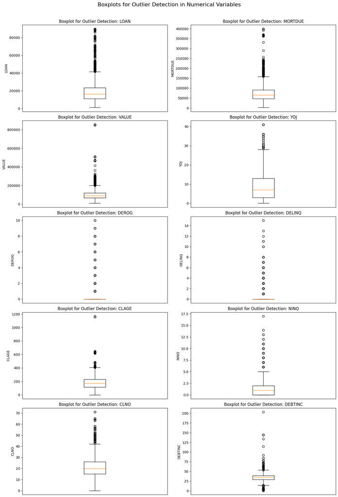

```python
import pandas as pd
import matplotlib.pyplot as plt

# List of numerical columns to check for outliers (excluding the binary target 'BAD')
numerical_cols = [
    'LOAN', 'MORTDUE', 'VALUE', 'YOJ', 'DEROG',
    'DELINQ', 'CLAGE', 'NINQ', 'CLNO', 'DEBTINC'
]

# Set up the plot layout: 5 rows, 2 columns
fig, axes = plt.subplots(nrows=5, ncols=2, figsize=(14, 20))
fig.subplots_adjust(hspace=0.4, wspace=0.3)
axes = axes.flatten()

# Generate boxplots for each numerical column on the original data
for i, col in enumerate(numerical_cols):
    # Boxplots require non-null data, so we use .dropna() to plot only existing values
    plot_data = df_Loan_original[col].dropna()

    axes[i].boxplot(plot_data)
    axes[i].set_title(f'Boxplot for Outlier Detection: {col}', fontsize=12)
    axes[i].set_ylabel(col, fontsize=10)
    # Remove x-axis tick labels for cleaner look
    axes[i].set_xticks([])

# Hide any unused subplots
for j in range(len(numerical_cols), len(axes)):
    fig.delaxes(axes[j])

plt.suptitle('Boxplots for Outlier Detection in Numerical Variables', fontsize=16, y=1.02)
plt.tight_layout(rect=[0, 0, 1, 1.01])

# Save the plot
boxplot_filename_detection = 'outlier_detection_boxplots.png'
plt.savefig(boxplot_filename_detection)
print(f"Boxplots for outlier detection saved as {boxplot_filename_detection}")
```

**3.3.4 Detecting Outliers using Interquartile Range (IQR) Method**

```python
# Select the numerical column for outlier detection. Using DEBTINC (Debt-to-Income Ratio)
column_name = 'DEBTINC'
data = df_Loan[column_name].dropna() # Drop NaN values for accurate IQR calculation

# 1. Calculate Q1 and Q3
Q1 = data.quantile(0.25)
Q3 = data.quantile(0.75)

# 2. Calculate the Interquartile Range (IQR)
IQR = Q3 - Q1

# 3. Determine the outlier bounds
lower_bound = Q1 - (1.5 * IQR)
upper_bound = Q3 + (1.5 * IQR)

# 4. Identify outliers
outliers = data[(data < lower_bound) | (data > upper_bound)]

# Calculate statistics
total_data_points = len(data)
outlier_count = len(outliers)
outlier_percentage = (outlier_count / total_data_points) * 100

print(f"--- Outlier Detection using IQR Method for '{column_name}' ---")
print(f"Q1 (25th Percentile): {Q1:.3f}")
print(f"Q3 (75th Percentile): {Q3:.3f}")
print(f"IQR: {IQR:.3f}")
print(f"Lower Bound (Q1 - 1.5*IQR): {lower_bound:.3f}")
print(f"Upper Bound (Q3 + 1.5*IQR): {upper_bound:.3f}")
print("-" * 55)
print(f"Total non-missing data points: {total_data_points}")
print(f"Number of Outliers detected: {outlier_count}")
print(f"Percentage of Outliers: {outlier_percentage:.2f}%")
```

```
--- Outlier Detection using IQR Method for 'DEBTINC' ---
Q1 (25th Percentile): 30.763
Q3 (75th Percentile): 37.950
IQR: 7.187
Lower Bound (Q1 - 1.5*IQR): 19.983
Upper Bound (Q3 + 1.5*IQR): 48.730
-------------------------------------------------------
Total non-missing data points: 5960
Number of Outliers detected: 247
Percentage of Outliers: 4.14%
```

```python
numerical_cols = df_Loan.select_dtypes(include=np.number).columns.drop('BAD', errors='ignore')

print("--- Outlier Detection using IQR Method for All Numerical Variables ---")
for column_name in numerical_cols:
    data = df_Loan[column_name].dropna() # Drop NaN values for accurate IQR calculation

    # 1. Calculate Q1 and Q3
    Q1 = data.quantile(0.25)
    Q3 = data.quantile(0.75)

    # 2. Calculate the Interquartile Range (IQR)
    IQR = Q3 - Q1

    # 3. Determine the outlier bounds
    lower_bound = Q1 - (1.5 * IQR)
    upper_bound = Q3 + (1.5 * IQR)

    # 4. Identify outliers
    outliers = data[(data < lower_bound) | (data > upper_bound)]

    # Calculate statistics
    total_data_points = len(data)
    outlier_count = len(outliers)
    outlier_percentage = (outlier_count / total_data_points) * 100

    print(f"\n--- Column: '{column_name}' ---")
    print(f"Q1 (25th Percentile): {Q1:.3f}")
    print(f"Q3 (75th Percentile): {Q3:.3f}")
    print(f"IQR: {IQR:.3f}")
    print(f"Lower Bound (Q1 - 1.5*IQR): {lower_bound:.3f}")
    print(f"Upper Bound (Q3 + 1.5*IQR): {upper_bound:.3f}")
    print(f"Number of Outliers detected: {outlier_count}")
    print(f"Percentage of Outliers: {outlier_percentage:.2f}%")
```

```
--- Outlier Detection using IQR Method for All Numerical Variables ---

--- Column: 'LOAN' ---
Q1 (25th Percentile): 11100.000
Q3 (75th Percentile): 23300.000
IQR: 12200.000
Lower Bound (Q1 - 1.5*IQR): -7200.000
Upper Bound (Q3 + 1.5*IQR): 41600.000
Number of Outliers detected: 256
Percentage of Outliers: 4.30%

--- Column: 'MORTDUE' ---
Q1 (25th Percentile): 48139.000
Q3 (75th Percentile): 88200.250
IQR: 40061.250
Lower Bound (Q1 - 1.5*IQR): -11952.875
Upper Bound (Q3 + 1.5*IQR): 148292.125
Number of Outliers detected: 308
Percentage of Outliers: 5.17%

--- Column: 'VALUE' ---
Q1 (25th Percentile): 66489.500
Q3 (75th Percentile): 119004.750
IQR: 52515.250
Lower Bound (Q1 - 1.5*IQR): -12283.375
Upper Bound (Q3 + 1.5*IQR): 197777.625
Number of Outliers detected: 347
Percentage of Outliers: 5.82%

--- Column: 'YOJ' ---
Q1 (25th Percentile): 3.000
Q3 (75th Percentile): 12.000
IQR: 9.000
Lower Bound (Q1 - 1.5*IQR): -10.500
Upper Bound (Q3 + 1.5*IQR): 25.500
Number of Outliers detected: 211
Percentage of Outliers: 3.54%

--- Column: 'DEROG' ---
Q1 (25th Percentile): 0.000
```

[output cut: 36 more lines]

```
Q3 (75th Percentile): 26.000
IQR: 11.000
Lower Bound (Q1 - 1.5*IQR): -1.500
Upper Bound (Q3 + 1.5*IQR): 42.500
Number of Outliers detected: 219
Percentage of Outliers: 3.67%

--- Column: 'DEBTINC' ---
Q1 (25th Percentile): 30.763
Q3 (75th Percentile): 37.950
IQR: 7.187
Lower Bound (Q1 - 1.5*IQR): 19.983
Upper Bound (Q3 + 1.5*IQR): 48.730
Number of Outliers detected: 247
Percentage of Outliers: 4.14%
```

```python
# Identify numerical columns for analysis
# Exclude the binary target variable 'BAD' from numerical analysis for outliers
numerical_cols = df_Loan.select_dtypes(include=np.number).columns.tolist()
if 'BAD' in numerical_cols:
    numerical_cols.remove('BAD')

outlier_results = []

print("Starting outlier detection using IQR method across all numerical variables...\n")

for col in numerical_cols:
    # Use dropna() to handle missing values before calculation
    data = df_Loan[col].dropna()

    if len(data) == 0:
        continue # Skip if the column is entirely missing

    # Calculate Q1, Q3, and IQR
    Q1 = data.quantile(0.25)
    Q3 = data.quantile(0.75)
    IQR = Q3 - Q1

    # Calculate outlier bounds
    lower_bound = Q1 - (1.5 * IQR)
    upper_bound = Q3 + (1.5 * IQR)

    # Identify and count outliers
    outliers = data[(data < lower_bound) | (data > upper_bound)]

    total_non_missing = len(data)
    outlier_count = len(outliers)
    outlier_percentage = (outlier_count / total_non_missing) * 100

    # Store results
    outlier_results.append({
        'Variable': col,
        'Q1': Q1,
        'Q3': Q3,
        'IQR': IQR,
        'Lower Bound': lower_bound,
        'Upper Bound': upper_bound,
        'Total Non-Missing': total_non_missing,
        'Outlier Count': outlier_count,
        'Outlier %': f"{outlier_percentage:.2f}%"
    })

# Convert results to a DataFrame for clear presentation
results_df = pd.DataFrame(outlier_results)

# Sort the results by the percentage of outliers
results_df['Outlier % Numeric'] = results_df['Outlier %'].str.replace('%', '').astype(float)
results_df = results_df.sort_values(by='Outlier % Numeric', ascending=False).drop(columns='Outlier % Numeric')

# Format the numerical columns for better readability
for col in ['Q1', 'Q3', 'IQR', 'Lower Bound', 'Upper Bound']:
    results_df[col] = results_df[col].map('{:.2f}'.format)

# Print the final table
print(results_df.to_markdown(index=False))
```

```
Starting outlier detection using IQR method across all numerical variables...

| Variable   |       Q1 |        Q3 |      IQR |   Lower Bound |   Upper Bound |   Total Non-Missing |   Outlier Count | Outlier %   |
|:-----------|---------:|----------:|---------:|--------------:|--------------:|--------------------:|----------------:|:------------|
| DELINQ     |     0    |      0    |     0    |          0    |          0    |                5960 |            1201 | 20.15%      |
| DEROG      |     0    |      0    |     0    |          0    |          0    |                5960 |             725 | 12.16%      |
| VALUE      | 66489.5  | 119005    | 52515.2  |     -12283.4  |     197778    |                5960 |             347 | 5.82%       |
| MORTDUE    | 48139    |  88200.2  | 40061.2  |     -11952.9  |     148292    |                5960 |             308 | 5.17%       |
| LOAN       | 11100    |  23300    | 12200    |      -7200    |      41600    |                5960 |             256 | 4.30%       |
| DEBTINC    |    30.76 |     37.95 |     7.19 |         19.98 |         48.73 |                5960 |             247 | 4.14%       |
| CLNO       |    15    |     26    |    11    |         -1.5  |         42.5  |                5960 |             219 | 3.67%       |
| YOJ        |     3    |     12    |     9    |        -10.5  |         25.5  |                5960 |             211 | 3.54%       |
| NINQ       |     0    |      2    |     2    |         -3    |          5    |                5960 |             177 | 2.97%       |
| CLAGE      |   117.37 |    227.14 |   109.77 |        -47.29 |        391.8  |                5960 |              66 | 1.11%       |
```

All numerical columns have outliers

### **3.3.2 Treating Outliers**

```python
def cap_outliers_iqr(df, column):
    Q1 = df[column].quantile(0.25)
    Q3 = df[column].quantile(0.75)
    IQR = Q3 - Q1
    lower_bound = Q1 - 1.5 * IQR
    upper_bound = Q3 + 1.5 * IQR
    # Cap the outliers
    df[column] = df[column].clip(lower=lower_bound, upper=upper_bound)
    return df

print("--- Outlier Treatment (Capping using IQR) ---")

numerical_cols = df_Loan.select_dtypes(include=np.number).columns.drop('BAD', errors='ignore')

for col in numerical_cols:
    initial_min = df_Loan[col].min()
    initial_max = df_Loan[col].max()
    df_Loan = cap_outliers_iqr(df_Loan.copy(), col)
    capped_min = df_Loan[col].min()
    capped_max = df_Loan[col].max()
    print(f"Column '{col}': Min changed from {initial_min:.2f} to {capped_min:.2f}, Max changed from {initial_max:.2f} to {capped_max:.2f}")

print("\nOutlier treatment applied to all numerical columns (excluding 'BAD').")
```

```
--- Outlier Treatment (Capping using IQR) ---
Column 'LOAN': Min changed from 1100.00 to 1100.00, Max changed from 89900.00 to 41600.00
Column 'MORTDUE': Min changed from 2063.00 to 2063.00, Max changed from 399550.00 to 148292.12
Column 'VALUE': Min changed from 8000.00 to 8000.00, Max changed from 855909.00 to 197777.62
Column 'YOJ': Min changed from 0.00 to 0.00, Max changed from 41.00 to 25.50
Column 'DEROG': Min changed from 0.00 to 0.00, Max changed from 10.00 to 0.00
Column 'DELINQ': Min changed from 0.00 to 0.00, Max changed from 15.00 to 0.00
Column 'CLAGE': Min changed from 0.00 to 0.00, Max changed from 1168.23 to 391.80
Column 'NINQ': Min changed from 0.00 to 0.00, Max changed from 17.00 to 5.00
Column 'CLNO': Min changed from 0.00 to 0.00, Max changed from 71.00 to 42.50
Column 'DEBTINC': Min changed from 0.52 to 19.98, Max changed from 203.31 to 48.73

Outlier treatment applied to all numerical columns (excluding 'BAD').
```

```python
#Define code for identifying columns to drop
# Removing unwanted variables (if any)
columns_to_drop = []  # Specify columns you may want to drop
df_Loan.drop(columns=columns_to_drop, axis=1, inplace=True)

# Display final dataset info
print("\nProcessed Data Info:")
df_Loan.info()
```

```
Processed Data Info:
<class 'pandas.core.frame.DataFrame'>
RangeIndex: 5960 entries, 0 to 5959
Data columns (total 13 columns):
 #   Column   Non-Null Count  Dtype
---  ------   --------------  -----
 0   BAD      5960 non-null   int64
 1   LOAN     5960 non-null   int64
 2   MORTDUE  5960 non-null   float64
 3   VALUE    5960 non-null   float64
 4   REASON   5960 non-null   object
 5   JOB      5960 non-null   object
 6   YOJ      5960 non-null   float64
 7   DEROG    5960 non-null   float64
 8   DELINQ   5960 non-null   float64
 9   CLAGE    5960 non-null   float64
 10  NINQ     5960 non-null   float64
 11  CLNO     5960 non-null   float64
 12  DEBTINC  5960 non-null   float64
dtypes: float64(9), int64(2), object(2)
memory usage: 605.4+ KB
```

```python
# Confirming the Outliers have been treated
numerical_cols = df_Loan.select_dtypes(include=np.number).columns.tolist()
if 'BAD' in numerical_cols:
    numerical_cols.remove('BAD')

outlier_results = []

print("Starting outlier detection using IQR method across all numerical variables...\n")

for col in numerical_cols:
    # Use dropna() to handle missing values before calculation
    data = df_Loan[col].dropna()

    if len(data) == 0:
        continue # Skip if the column is entirely missing

    # Calculate Q1, Q3, and IQR
    Q1 = data.quantile(0.25)
    Q3 = data.quantile(0.75)
    IQR = Q3 - Q1

    # Calculate outlier bounds
    lower_bound = Q1 - (1.5 * IQR)
    upper_bound = Q3 + (1.5 * IQR)

    # Identify and count outliers
    outliers = data[(data < lower_bound) | (data > upper_bound)]

    total_non_missing = len(data)
    outlier_count = len(outliers)
    outlier_percentage = (outlier_count / total_non_missing) * 100

    # Store results
    outlier_results.append({
        'Variable': col,
        'Q1': Q1,
        'Q3': Q3,
        'IQR': IQR,
        'Lower Bound': lower_bound,
        'Upper Bound': upper_bound,
        'Total Non-Missing': total_non_missing,
        'Outlier Count': outlier_count,
        'Outlier %': f"{outlier_percentage:.2f}%"
    })

# Convert results to a DataFrame for clear presentation
results_df = pd.DataFrame(outlier_results)

# Sort the results by the percentage of outliers
results_df['Outlier % Numeric'] = results_df['Outlier %'].str.replace('%', '').astype(float)
results_df = results_df.sort_values(by='Outlier % Numeric', ascending=False).drop(columns='Outlier % Numeric')

# Format the numerical columns for better readability
for col in ['Q1', 'Q3', 'IQR', 'Lower Bound', 'Upper Bound']:
    results_df[col] = results_df[col].map('{:.2f}'.format)

# Print the final table
print(results_df.to_markdown(index=False))
```

```
Starting outlier detection using IQR method across all numerical variables...

| Variable   |       Q1 |        Q3 |      IQR |   Lower Bound |   Upper Bound |   Total Non-Missing |   Outlier Count | Outlier %   |
|:-----------|---------:|----------:|---------:|--------------:|--------------:|--------------------:|----------------:|:------------|
| LOAN       | 11100    |  23300    | 12200    |      -7200    |      41600    |                5960 |               0 | 0.00%       |
| MORTDUE    | 48139    |  88200.2  | 40061.2  |     -11952.9  |     148292    |                5960 |               0 | 0.00%       |
| VALUE      | 66489.5  | 119005    | 52515.2  |     -12283.4  |     197778    |                5960 |               0 | 0.00%       |
| YOJ        |     3    |     12    |     9    |        -10.5  |         25.5  |                5960 |               0 | 0.00%       |
| DEROG      |     0    |      0    |     0    |          0    |          0    |                5960 |               0 | 0.00%       |
| DELINQ     |     0    |      0    |     0    |          0    |          0    |                5960 |               0 | 0.00%       |
| CLAGE      |   117.37 |    227.14 |   109.77 |        -47.29 |        391.8  |                5960 |               0 | 0.00%       |
| NINQ       |     0    |      2    |     2    |         -3    |          5    |                5960 |               0 | 0.00%       |
| CLNO       |    15    |     26    |    11    |         -1.5  |         42.5  |                5960 |               0 | 0.00%       |
| DEBTINC    |    30.76 |     37.95 |     7.19 |         19.98 |         48.73 |                5960 |               0 | 0.00%       |
```

```
Boxplots for outlier detection saved as outlier_detection_boxplots.png
```

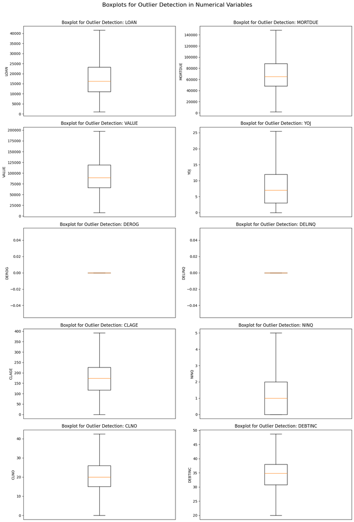

```python
#Using Visualization to confirm the Outliers have been treated
import pandas as pd
import matplotlib.pyplot as plt

# List of numerical columns to check for outliers (excluding the binary target 'BAD')
numerical_cols = [
    'LOAN', 'MORTDUE', 'VALUE', 'YOJ', 'DEROG',
    'DELINQ', 'CLAGE', 'NINQ', 'CLNO', 'DEBTINC'
]

# Set up the plot layout: 5 rows, 2 columns
fig, axes = plt.subplots(nrows=5, ncols=2, figsize=(14, 20))
fig.subplots_adjust(hspace=0.4, wspace=0.3)
axes = axes.flatten()

# Generate boxplots for each numerical column on the original data
for i, col in enumerate(numerical_cols):
    # Boxplots require non-null data, so we use .dropna() to plot only existing values
    plot_data = df_Loan[col].dropna()

    axes[i].boxplot(plot_data)
    axes[i].set_title(f'Boxplot for Outlier Detection: {col}', fontsize=12)
    axes[i].set_ylabel(col, fontsize=10)
    # Remove x-axis tick labels for cleaner look
    axes[i].set_xticks([])

# Hide any unused subplots
for j in range(len(numerical_cols), len(axes)):
    fig.delaxes(axes[j])

plt.suptitle('Boxplots for Outlier Detection in Numerical Variables', fontsize=16, y=1.02)
plt.tight_layout(rect=[0, 0, 1, 1.01])

# Save the plot
boxplot_filename_detection = 'outlier_detection_boxplots.png'
plt.savefig(boxplot_filename_detection)
print(f"Boxplots for outlier detection saved as {boxplot_filename_detection}")
```

## **3.4 Variable transformation**

Variable transformation is a fundamental and mandatory step in preparing the loan default data for modeling, ensuring features meet the assumptions of certain algorithms and maximizing predictive power. The process involves structural changes to variables based on their distribution, predictive relationships, and data type. Based on the nature of the variable the following was done or will be considered during modelling.

**3.5.1 Handling Numerical Skewness and Outliers**

The VALUE and LOAN variables were noted to be positively skewed, meaning their distributions have long tails towards high values and were confirmed to contain significant outliers in the IQR analysis. Logarithmic Transformation may be considered during the modeling phase. Applying the logarithm transformation compresses the range of high-magnitude values, stabilizing the variance, and making the distribution more symmetrical (closer to a Gaussian shape). This is particularly important if Logistic Regression is used, as linear models assume features have a normal or near-normal distribution.

**3.5.2 Feature Engineering **

This may also be considered for MORTDUE and VALUE variables during the modelling phase. The variables were noted to have a high correlation of 0.876, between them. This suggests multicollinearity or redundancy. Transformation will create powerful, domain-specific features that address multicollinearity and improve model interpretability. A ratio variable may be created to address this issue.

**3.5.3 Encoding Categorical Variables**

The categorical features REASON and JOB required transformation into a numerical format suitable for machine learning algorithms. The transformation used was One-Hot Encoding (OHE) or Target/Mean Encoding. OHE creates binary (0 or 1) columns for each unique category, preventing the model from inferring an ordinal relationship (e.g., assuming 'HomeImp' is greater than 'DebtCon').

```python
# 2. Perform One-Hot Encoding
# drop_first=True is used to avoid multicollinearity
df_final = pd.get_dummies(df_Loan, columns=categorical_cols, drop_first=True)

# 3. Explicitly transform the encoded columns (which are uint8) to int64
encoded_cols = [col for col in df_final.columns if col.startswith('REASON_') or col.startswith('JOB_')]
for col in encoded_cols:
    df_final[col] = df_final[col].astype('int64')

# 4. Display the results
print("--- Transformed DataFrame Info (Confirming int64 Types) ---")
df_final.info()
print("\n--- Transformed DataFrame Head (Showing 0s and 1s) ---")
# Display a selection of columns: Target, Loan Amount, Debt-to-Income, and all new encoded columns
display_cols = ['BAD', 'LOAN', 'DEBTINC'] + encoded_cols
print(df_final[display_cols].head().to_markdown(index=False, numalign="left", stralign="left"))

# 5. Save the transformed data to a new CSV file
df_final.to_csv('loan_transformed.csv', index=False)
print("\nTransformed DataFrame saved to loan_transformed.csv")
```

```
--- Transformed DataFrame Info (Confirming int64 Types) ---
<class 'pandas.core.frame.DataFrame'>
RangeIndex: 5960 entries, 0 to 5959
Data columns (total 17 columns):
 #   Column          Non-Null Count  Dtype
---  ------          --------------  -----
 0   BAD             5960 non-null   int64
 1   LOAN            5960 non-null   int64
 2   MORTDUE         5960 non-null   float64
 3   VALUE           5960 non-null   float64
 4   YOJ             5960 non-null   float64
 5   DEROG           5960 non-null   float64
 6   DELINQ          5960 non-null   float64
 7   CLAGE           5960 non-null   float64
 8   NINQ            5960 non-null   float64
 9   CLNO            5960 non-null   float64
 10  DEBTINC         5960 non-null   float64
 11  REASON_HomeImp  5960 non-null   int64
 12  JOB_Office      5960 non-null   int64
 13  JOB_Other       5960 non-null   int64
 14  JOB_ProfExe     5960 non-null   int64
 15  JOB_Sales       5960 non-null   int64
 16  JOB_Self        5960 non-null   int64
dtypes: float64(9), int64(8)
memory usage: 791.7 KB

--- Transformed DataFrame Head (Showing 0s and 1s) ---
| BAD   | LOAN   | DEBTINC   | REASON_HomeImp   | JOB_Office   | JOB_Other   | JOB_ProfExe   | JOB_Sales   | JOB_Self   |
|:------|:-------|:----------|:-----------------|:-------------|:------------|:--------------|:------------|:-----------|
| 1     | 1100   | 34.8183   | 1                | 0            | 1           | 0             | 0           | 0          |
| 1     | 1300   | 34.8183   | 1                | 0            | 1           | 0             | 0           | 0          |
| 1     | 1500   | 34.8183   | 1                | 0            | 1           | 0             | 0           | 0          |
| 1     | 1500   | 34.8183   | 0                | 0            | 1           | 0             | 0           | 0          |
| 0     | 1700   | 34.8183   | 1                | 1            | 0           | 0             | 0           | 0          |

Transformed DataFrame saved to loan_transformed.csv
```

```python
df_final.head()
```

|  | BAD | LOAN | MORTDUE | VALUE | YOJ | DEROG | DELINQ | CLAGE | NINQ | CLNO | DEBTINC | REASON_HomeImp | JOB_Office | JOB_Other | JOB_ProfExe | JOB_Sales | JOB_Self |
| --- | --- | --- | --- | --- | --- | --- | --- | --- | --- | --- | --- | --- | --- | --- | --- | --- | --- |
| 0 | 1 | 1100 | 25860.000 | 39025.000 | 10.500 | 0.000 | 0.000 | 94.367 | 1.000 | 9.000 | 34.818 | 1 | 0 | 1 | 0 | 0 | 0 |
| 1 | 1 | 1300 | 70053.000 | 68400.000 | 7.000 | 0.000 | 0.000 | 121.833 | 0.000 | 14.000 | 34.818 | 1 | 0 | 1 | 0 | 0 | 0 |
| 2 | 1 | 1500 | 13500.000 | 16700.000 | 4.000 | 0.000 | 0.000 | 149.467 | 1.000 | 10.000 | 34.818 | 1 | 0 | 1 | 0 | 0 | 0 |
| 3 | 1 | 1500 | 65019.000 | 89235.500 | 7.000 | 0.000 | 0.000 | 173.467 | 1.000 | 20.000 | 34.818 | 0 | 0 | 1 | 0 | 0 | 0 |
| 4 | 0 | 1700 | 97800.000 | 112000.000 | 3.000 | 0.000 | 0.000 | 93.333 | 0.000 | 14.000 | 34.818 | 1 | 1 | 0 | 0 | 0 | 0 |

### **3.5 Addition of new variables**

Based on the analysis so far conducted, the primary goal of adding new variables would be to:

a) Increase Predictive Power: Create features that capture non-linear risk aspects.

b) Solve Multicollinearity: Combine correlated raw features into a single, more meaningful ratio.

During modelling the following may be considered:

a) Variable addition which may focus on creating financial ratios, which are standard in credit risk assessment and often possess higher predictive power than their raw components. Some of the variables based on ratios to be considered are Loan-to-Value (LTV) Ratio((LOAN+MORGDUE)/VALUE), Asset Value (Home Equity) (VALUE/MORGDUE) and Debt-to-Credit Limit Ratio(LOAN/CLNO)

b) Interaction Features may also be included. These variables are added to capture non-linear risk profiles where the effect of one feature depends on the level of another. An example is (Job Tenure vs. Credit Tenure): A ratio that assesses if the stability of the current job is proportional to the length of the credit history.

c) Binning and Discretization may also be used. This transformation converts highly continuous variables into discrete, ordinal groups, which helps capture non-linear relationships. An example is Age of Credit History (CLAGE). This could be binned (e.g., $< 5$ years, $5-10$ years, $10+$ years) to isolate specific segments where credit stability drastically changes. This is effective if the relationship between CLAGE and BAD is not smooth but drops sharply after a certain credit age threshold.

# **4.0 Exploratory Data Analysis**

## **4.1 Univariate Analysis**

### **4.1.1 Categorical Variables**

```
Bar charts for categorical variables saved as categorical_distribution_2rows_1col.png
```

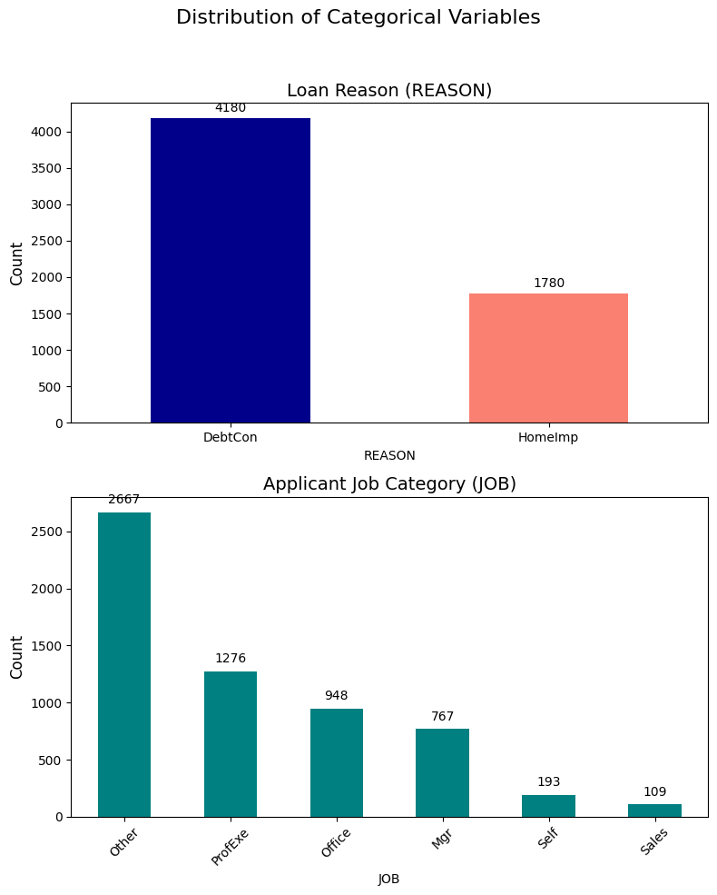

```python
# Identify Categorical Columns
categorical_cols = ['REASON', 'JOB']

# Impute Missing Categorical Values with the Mode
for col in categorical_cols:
    mode_value = df_Loan[col].mode()[0]
    df_Loan[col].fillna(mode_value, inplace=True)

# Set up the plot layout: 2 rows, 1 column
fig, axes = plt.subplots(nrows=2, ncols=1, figsize=(8, 10))
plt.subplots_adjust(hspace=0.4) # Adjusting horizontal spacing for vertical layout
plt.suptitle('Distribution of Categorical Variables', fontsize=16)

# 1. Plot REASON distribution (Bar Chart)
reason_counts = df_Loan['REASON'].value_counts().sort_index()
reason_counts.plot(kind='bar', ax=axes[0], color=['darkblue', 'salmon'])
axes[0].set_title('Loan Reason (REASON)', fontsize=14)
axes[0].set_ylabel('Count', fontsize=12)
axes[0].tick_params(axis='x', rotation=0)
for i, count in enumerate(reason_counts):
    axes[0].text(i, count + 50, str(count), ha='center', va='bottom')

# 2. Plot JOB distribution (Bar Chart) - sorted by count
job_counts = df_Loan['JOB'].value_counts().sort_values(ascending=False)
job_counts.plot(kind='bar', ax=axes[1], color='teal')
axes[1].set_title('Applicant Job Category (JOB)', fontsize=14)
axes[1].set_ylabel('Count', fontsize=12)
axes[1].tick_params(axis='x', rotation=45)
for i, count in enumerate(job_counts):
    # Adjusting text placement for readability with rotated ticks
    axes[1].text(i, count + 50, str(count), ha='center', va='bottom', fontsize=10)

# Save the plot
plt.tight_layout(rect=[0, 0, 1, 0.95])
plot_filename = 'categorical_distribution_2rows_1col.png'
plt.savefig(plot_filename)
print(f"Bar charts for categorical variables saved as {plot_filename}")
```

```python
for col in df_Loan.select_dtypes(exclude='number').columns:
    if col == 'BAD':
        continue
    print(f"\n🔹 {col}\n")

    counts = df_Loan[col].value_counts()
    percentages = df_Loan[col].value_counts(normalize=True) * 100

    # Combine counts and percentages into a single DataFrame for better display
    combined_df = pd.DataFrame({'Count': counts, 'Percentage': percentages.round(2)})
    print(combined_df.to_markdown(numalign="left", stralign="left"))
```

```
🔹 REASON

| REASON   | Count   | Percentage   |
|:---------|:--------|:-------------|
| DebtCon  | 4180    | 70.13        |
| HomeImp  | 1780    | 29.87        |

🔹 JOB

| JOB     | Count   | Percentage   |
|:--------|:--------|:-------------|
| Other   | 2667    | 44.75        |
| ProfExe | 1276    | 21.41        |
| Office  | 948     | 15.91        |
| Mgr     | 767     | 12.87        |
| Self    | 193     | 3.24         |
| Sales   | 109     | 1.83         |
```

### **Findings:**

The resulting bar charts illustrate the following distributions:

**1. Loan Reason (REASON)**

b) Home Improvement (HomeImp) is the only other category, with 1,780 counts.

The dataset is heavily skewed toward debt consolidation loans, meaning the predictive model will primarily learn the risk profile associated with this type of loan purpose.

**2. Applicant Job Category (JOB)**

b) ProfExe (Professional/Executive) is the second largest with 1,276 counts.

c) The remaining categories, including Office, Mgr (Manager), Self (Self-Employed), and Sales, are significantly smaller.

The large proportion of applicants in the general Other job category suggests this variable's predictive power might be limited or that a significant portion of the applicant pool belongs to non-standard or varied employment types.

### **4.1.2 Numerical Variables**

```
Boxplots saved as numerical_boxplots_1column.png
```

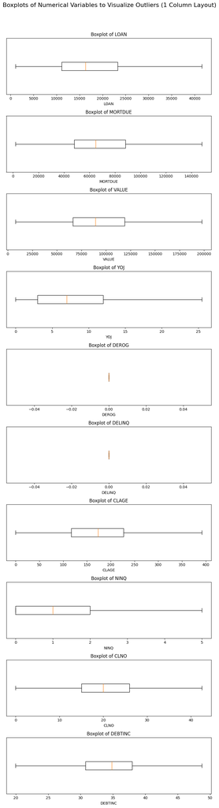

```python
# List of numerical columns to check for outliers (excluding the binary target 'BAD')
numerical_cols = [
    'LOAN', 'MORTDUE', 'VALUE', 'YOJ', 'DEROG',
    'DELINQ', 'CLAGE', 'NINQ', 'CLNO', 'DEBTINC'

]

# Set up the plot layout: 10 rows, 1 column
fig, axes = plt.subplots(nrows=10, ncols=1, figsize=(8, 30))
fig.subplots_adjust(hspace=0.6) # Increase vertical spacing
axes = axes.flatten()

# Generate boxplots for each numerical column
for i, col in enumerate(numerical_cols):
    # Drop NaNs for plotting, as boxplots cannot handle null values
    plot_data = df_Loan[col].dropna()

    axes[i].boxplot(plot_data, vert=False) # Plot horizontally for better use of the narrow space
    axes[i].set_title(f'Boxplot of {col}', fontsize=12)
    axes[i].set_xlabel(col, fontsize=10)
    axes[i].set_yticks([]) # Remove y-axis tick labels

plt.suptitle('Boxplots of Numerical Variables to Visualize Outliers (1 Column Layout)', fontsize=16, y=1.0)
plt.tight_layout(rect=[0, 0, 1, 0.98])

# Save the plot
boxplot_filename = 'numerical_boxplots_1column.png'
plt.savefig(boxplot_filename)
print(f"Boxplots saved as {boxplot_filename}")
```

```
Boxplots saved as numerical_boxplots_1column.png
```

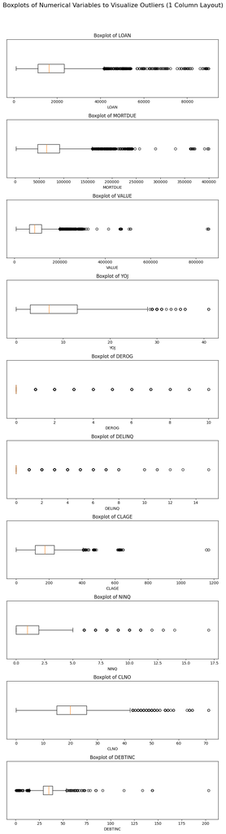

```python
#Ploting Numerical Variables Before Data Transformation


# List of numerical columns to check for outliers (excluding the binary target 'BAD')
numerical_cols = [
    'LOAN', 'MORTDUE', 'VALUE', 'YOJ', 'DEROG',
    'DELINQ', 'CLAGE', 'NINQ', 'CLNO', 'DEBTINC'
]

# Set up the plot layout: 10 rows, 1 column
fig, axes = plt.subplots(nrows=10, ncols=1, figsize=(8, 30))
fig.subplots_adjust(hspace=0.6) # Increase vertical spacing
axes = axes.flatten()

# Generate boxplots for each numerical column
for i, col in enumerate(numerical_cols):
    # Drop NaNs for plotting, as boxplots cannot handle null values
    plot_data = df_Loan_original[col].dropna()

    axes[i].boxplot(plot_data, vert=False) # Plot horizontally for better use of the narrow space
    axes[i].set_title(f'Boxplot of {col}', fontsize=12)
    axes[i].set_xlabel(col, fontsize=10)
    axes[i].set_yticks([]) # Remove y-axis tick labels

plt.suptitle('Boxplots of Numerical Variables to Visualize Outliers (1 Column Layout)', fontsize=16, y=1.0)
plt.tight_layout(rect=[0, 0, 1, 0.98])

# Save the plot
boxplot_filename = 'numerical_boxplots_1column.png'
plt.savefig(boxplot_filename)
print(f"Boxplots saved as {boxplot_filename}")
```

```
Loan amount summary statistics:
count    5960.000
mean    18607.970
std     11207.480
min      1100.000
25%     11100.000
50%     16300.000
75%     23300.000
max     89900.000
Name: LOAN, dtype: float64

Years at present job summary statistics:
count   5445.000
mean       8.922
std        7.574
min        0.000
25%        3.000
50%        7.000
75%       13.000
max       41.000
Name: YOJ, dtype: float64

Number of unique categories in REASON:
2

Counts of each category in REASON:
REASON
DebtCon    3928
HomeImp    1780
Name: count, dtype: int64

Number of unique categories in JOB:
6

Counts of each category in JOB:
JOB
Other      2388
ProfExe    1276
Office      948
Mgr         767
Self        193
Sales       109
Name: count, dtype: int64
```

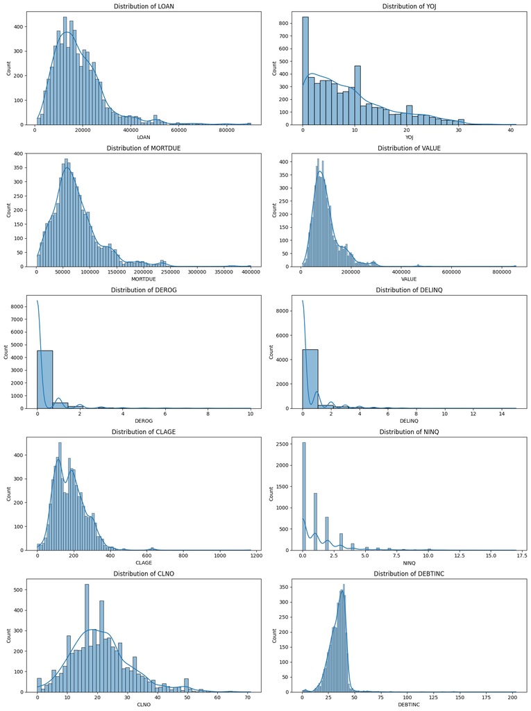

```python
print("Loan amount summary statistics:")
print(df_Loan_original["LOAN"].describe())

# YOJ
print("\nYears at present job summary statistics:")
print(df_Loan_original["YOJ"].describe())

# REASON
print("\nNumber of unique categories in REASON:")
print(df_Loan_original["REASON"].nunique())
print("\nCounts of each category in REASON:")
print(df_Loan_original["REASON"].value_counts())

# JOB
print("\nNumber of unique categories in JOB:")
print(df_Loan_original["JOB"].nunique())
print("\nCounts of each category in JOB:")
print(df_Loan_original["JOB"].value_counts())

# Histograms for numerical variables
num_vars = ['LOAN', 'YOJ', 'MORTDUE', 'VALUE', 'DEROG', 'DELINQ', 'CLAGE', 'NINQ', 'CLNO', 'DEBTINC']
fig, axes = plt.subplots(5, 2, figsize=(15, 20))

for idx, var in enumerate(num_vars):
    row, col = idx // 2, idx % 2
    sns.histplot(df_Loan_original[var], ax=axes[row, col], kde=True)
    axes[row, col].set_title(f"Distribution of {var}")

plt.tight_layout()
plt.show()
```

### **Findings for Numerical Columns EDA**

a) (DEROG, DELINQ, NINQ) - The boxes (interquartile range) are compressed near zero, with long tails of data points extending far above.Most applicants have clean credit, but extreme outliers exist representing applicants with high delinquencies or derogatory marks. These may require capping or transformation to prevent them from skewing the model.

b) (LOAN, MORTDUE, VALUE) - Show many outliers in the high-end of their range. There are applicants with loan amounts, mortgage amounts, and property values significantly higher than the median applicant.

c) DEBTINC - The central box is tight, but it has several extreme outliers stretching to very high values (e.g., $\sim203$). These extreme Debt-to-Income ratios should be treated as potential outliers that need to be capped or investigated, as they are likely influential data points.

d) (YOJ, CLAGE) - Both show strong evidence of outliers, particularly at the high end. CLAGE (age of credit line) has points suggesting very long credit histories, and YOJ (years at job) has high values, indicating highly stable applicants, though some high values may warrant checking for data entry errors.

The prevalence of outliers across all numerical features mandates the use of robust data processing techniques, such as log transformation for highly skewed variables and/or capping (winsorization) to limit the influence of extreme values, before training the predictive model.

# **4.2 Bivariate Analysis**

### **4.2.1 Categorical Variables**

```python
#Calculate the distribution of BAD for categorical variables as well as percentages
for col in df_Loan.select_dtypes(exclude='number').columns:
    if col == 'BAD':
        continue
    print(f"\n🔹 {col}\n")

    counts = df_Loan.groupby(col)['BAD'].value_counts()
    percentages = df_Loan.groupby(col)['BAD'].value_counts(normalize=True) * 100

    # Combine counts and percentages into a single DataFrame for better display
    combined_df = pd.DataFrame({'Count': counts, 'Percentage': percentages.round(2)})
    print(combined_df.to_markdown(numalign="left", stralign="left"))
```

```
🔹 REASON

|                | Count   | Percentage   |
|:---------------|:--------|:-------------|
| ('DebtCon', 0) | 3387    | 81.03        |
| ('DebtCon', 1) | 793     | 18.97        |
| ('HomeImp', 0) | 1384    | 77.75        |
| ('HomeImp', 1) | 396     | 22.25        |

🔹 JOB

|                | Count   | Percentage   |
|:---------------|:--------|:-------------|
| ('Mgr', 0)     | 588     | 76.66        |
| ('Mgr', 1)     | 179     | 23.34        |
| ('Office', 0)  | 823     | 86.81        |
| ('Office', 1)  | 125     | 13.19        |
| ('Other', 0)   | 2090    | 78.37        |
| ('Other', 1)   | 577     | 21.63        |
| ('ProfExe', 0) | 1064    | 83.39        |
| ('ProfExe', 1) | 212     | 16.61        |
| ('Sales', 0)   | 71      | 65.14        |
| ('Sales', 1)   | 38      | 34.86        |
| ('Self', 0)    | 135     | 69.95        |
| ('Self', 1)    | 58      | 30.05        |
```

```
Bivariate categorical plots saved as bivariate_categorical_plots_2rows.png
```

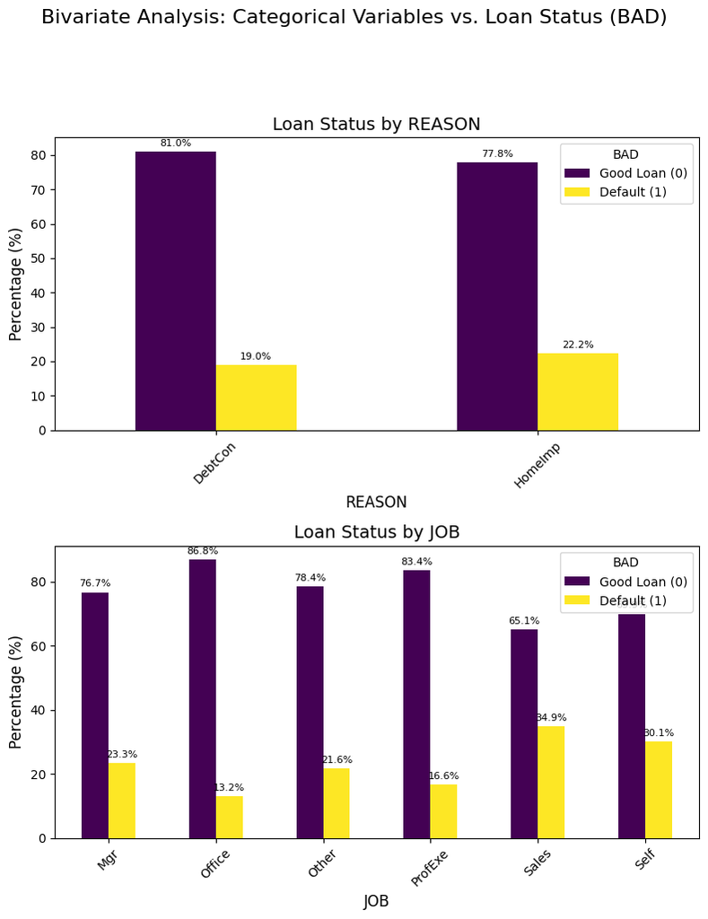

```python
import matplotlib.pyplot as plt
import seaborn as sns

categorical_cols = ['REASON', 'JOB']

# Change to 2 rows, 1 column layout with adjusted figure size
fig, axes = plt.subplots(nrows=2, ncols=1, figsize=(8, 10))
plt.subplots_adjust(hspace=0.6) # Adjust vertical spacing
axes = axes.flatten() # Flatten in case of single column for consistent indexing

plt.suptitle('Bivariate Analysis: Categorical Variables vs. Loan Status (BAD)', fontsize=16, y=1.02)

for i, col in enumerate(categorical_cols):
    # Calculate the proportion of BAD=0 and BAD=1 for each category
    # Using pd.crosstab and then normalizing to get percentages
    bad_proportions = pd.crosstab(df_Loan[col], df_Loan['BAD'], normalize='index') * 100

    bad_proportions.plot(kind='bar', stacked=False, ax=axes[i], cmap='viridis')
    axes[i].set_title(f'Loan Status by {col}', fontsize=14)
    axes[i].set_xlabel(col, fontsize=12)
    axes[i].set_ylabel('Percentage (%)', fontsize=12)
    axes[i].tick_params(axis='x', rotation=45)
    axes[i].legend(title='BAD', labels=['Good Loan (0)', 'Default (1)'], loc='upper right')

    # Add percentages on top of bars for clarity
    for container in axes[i].containers:
        for j, rect in enumerate(container):
            height = rect.get_height()
            if height > 0:
                axes[i].annotate(f'{height:.1f}%',
                                 xy=(rect.get_x() + rect.get_width() / 2, height),
                                 xytext=(0, 3),  # 3 points vertical offset
                                 textcoords="offset points",
                                 ha='center', va='bottom', fontsize=8)


plt.tight_layout(rect=[0, 0, 1, 0.95]) # Adjust layout to prevent title overlap
plot_filename = 'bivariate_categorical_plots_2rows.png' # Update filename
plt.savefig(plot_filename)
print(f"Bivariate categorical plots saved as {plot_filename}")
```

```
Larger bivariate numerical plot saved as bivariate_numerical_boxplots_large_1col.png
```

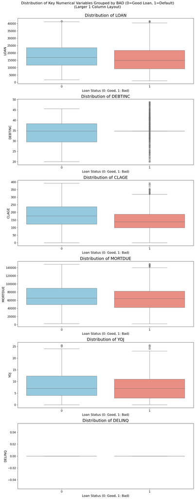

```python
# Selected 6 key numerical variables for Bivariate Analysis
numerical_cols_bivariate = [
    'LOAN', 'DEBTINC', 'CLAGE', 'MORTDUE', 'YOJ', 'DELINQ'
]

# Set up the plot layout: 6 rows, 1 column
# Doubling the size (increasing figsize from (8, 20) to (12, 30) for better display)
fig, axes = plt.subplots(nrows=6, ncols=1, figsize=(12, 30))
fig.subplots_adjust(hspace=0.4, wspace=0.3)
axes = axes.flatten()

plt.suptitle('Distribution of Key Numerical Variables Grouped by BAD (0=Good Loan, 1=Default)\n(Larger 1 Column Layout)', fontsize=16, y=1.01)

# Generate boxplots for each numerical column, grouped by BAD
for i, col in enumerate(numerical_cols_bivariate):
    # Use df_Loan as the data source and use string keys for palette
    sns.boxplot(x='BAD', y=col, data=df_Loan, ax=axes[i], palette={'0': 'skyblue', '1': 'salmon'})
    axes[i].set_title(f'Distribution of {col}', fontsize=18)
    axes[i].set_xlabel('Loan Status (0: Good, 1: Bad)', fontsize=14)
    axes[i].set_ylabel(col, fontsize=14)
    axes[i].tick_params(axis='both', labelsize=12)

# Save the plot
plt.tight_layout(rect=[0, 0, 1, 1.01])
plot_filename_large = 'bivariate_numerical_boxplots_large_1col.png'
plt.savefig(plot_filename_large)
print(f"Larger bivariate numerical plot saved as {plot_filename_large}")
```

### **Findings**

a) Loans for Home Improvement (HomeImp) have a slightly higher default rate (approx 22.2%) compared to loans for Debt Consolidation (DebtCon) (approx 19%). This suggests that the purpose of the loan is a differentiating factor in credit risk.

e) CLAGE - The Bad Loan (1) group tends to have a lower median and a box concentrated at lower values (younger credit history) than the Good Loan (0) group. Good Predictor: Longer, more established credit histories are associated with lower default risk.

g) MORTDUE-The medians are very close, and the distributions largely overlap. Weak Predictor: The amount of the existing mortgage does not appear to strongly influence the likelihood of default on this new loan.

# **4.3 Multivariate Analysis**

```python
# Separating numerical variables
numerical_col = df_Loan_original.select_dtypes(include=np.number).columns.tolist()

# Build correlation matrix for numerical columns
corr = df_Loan_original[numerical_col].corr()
display(corr)
```

|  | BAD | LOAN | MORTDUE | VALUE | YOJ | DEROG | DELINQ | CLAGE | NINQ | CLNO | DEBTINC |
| --- | --- | --- | --- | --- | --- | --- | --- | --- | --- | --- | --- |
| BAD | 1.000 | -0.075 | -0.048 | -0.030 | -0.060 | 0.276 | 0.354 | -0.170 | 0.175 | -0.004 | 0.200 |
| LOAN | -0.075 | 1.000 | 0.229 | 0.335 | 0.106 | -0.001 | -0.035 | 0.089 | 0.044 | 0.073 | 0.085 |
| MORTDUE | -0.048 | 0.229 | 1.000 | 0.876 | -0.088 | -0.050 | -0.001 | 0.140 | 0.031 | 0.324 | 0.155 |
| VALUE | -0.030 | 0.335 | 0.876 | 1.000 | 0.008 | -0.049 | -0.014 | 0.171 | -0.004 | 0.269 | 0.132 |
| YOJ | -0.060 | 0.106 | -0.088 | 0.008 | 1.000 | -0.066 | 0.038 | 0.202 | -0.072 | 0.025 | -0.056 |
| DEROG | 0.276 | -0.001 | -0.050 | -0.049 | -0.066 | 1.000 | 0.212 | -0.083 | 0.174 | 0.062 | 0.017 |
| DELINQ | 0.354 | -0.035 | -0.001 | -0.014 | 0.038 | 0.212 | 1.000 | 0.022 | 0.068 | 0.165 | 0.052 |
| CLAGE | -0.170 | 0.089 | 0.140 | 0.171 | 0.202 | -0.083 | 0.022 | 1.000 | -0.117 | 0.238 | -0.046 |
| NINQ | 0.175 | 0.044 | 0.031 | -0.004 | -0.072 | 0.174 | 0.068 | -0.117 | 1.000 | 0.088 | 0.141 |
| CLNO | -0.004 | 0.073 | 0.324 | 0.269 | 0.025 | 0.062 | 0.165 | 0.238 | 0.088 | 1.000 | 0.186 |
| DEBTINC | 0.200 | 0.085 | 0.155 | 0.132 | -0.056 | 0.017 | 0.052 | -0.046 | 0.141 | 0.186 | 1.000 |

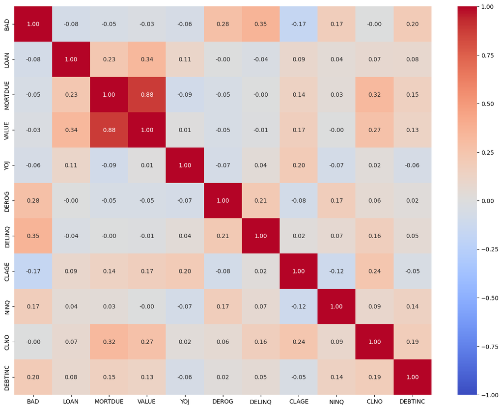

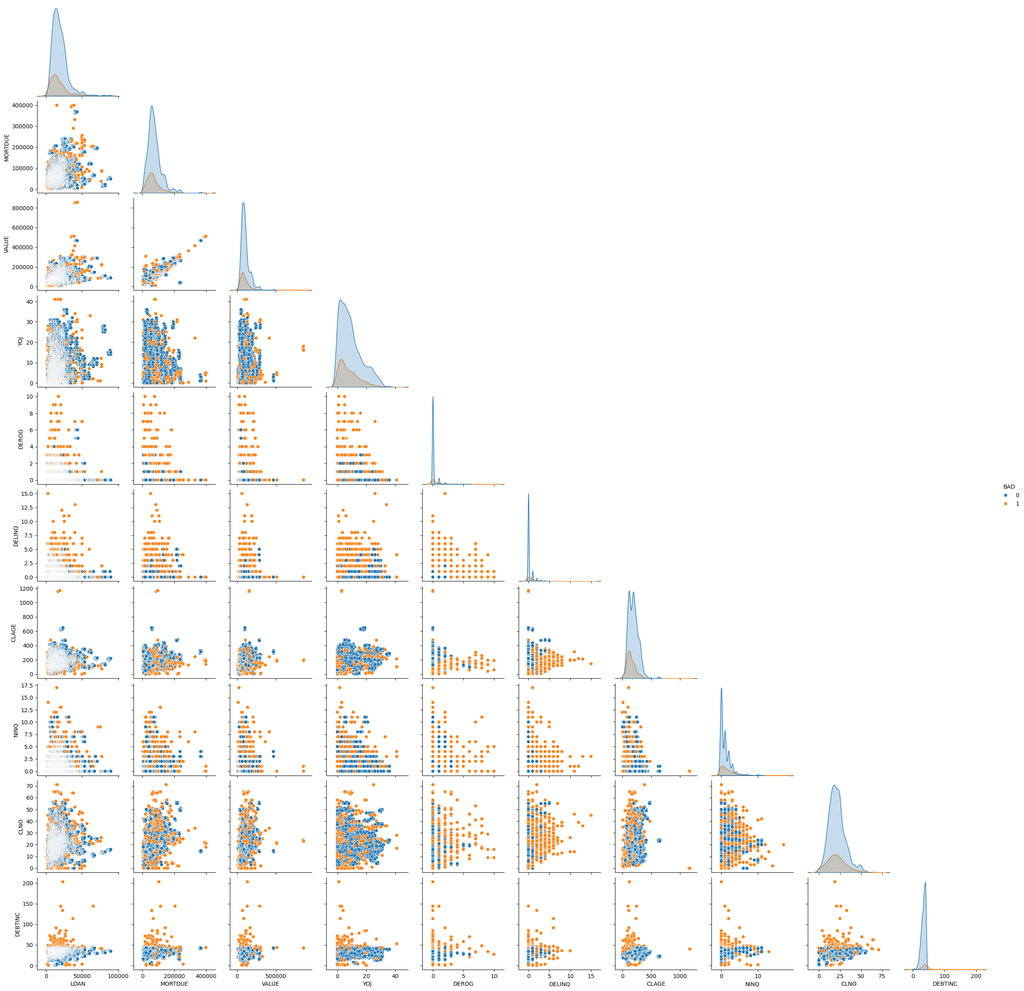

```python
# Separating numerical variables
numerical_col = df_Loan_original.select_dtypes(include=np.number).columns.tolist()

# Build correlation matrix for numerical columns
corr = df_Loan_original[numerical_col].corr()

# Plot the heatmap
plt.figure(figsize=(16, 12))
sns.heatmap(corr, cmap='coolwarm', vmax=1, vmin=-1,
            annot=True, fmt=".2f",
            xticklabels=corr.columns,
            yticklabels=corr.columns)

# Build pairplot for the data with hue = 'BAD'
sns.pairplot(df_Loan_original, hue='BAD', diag_kind='kde', corner=True)
plt.show()
```

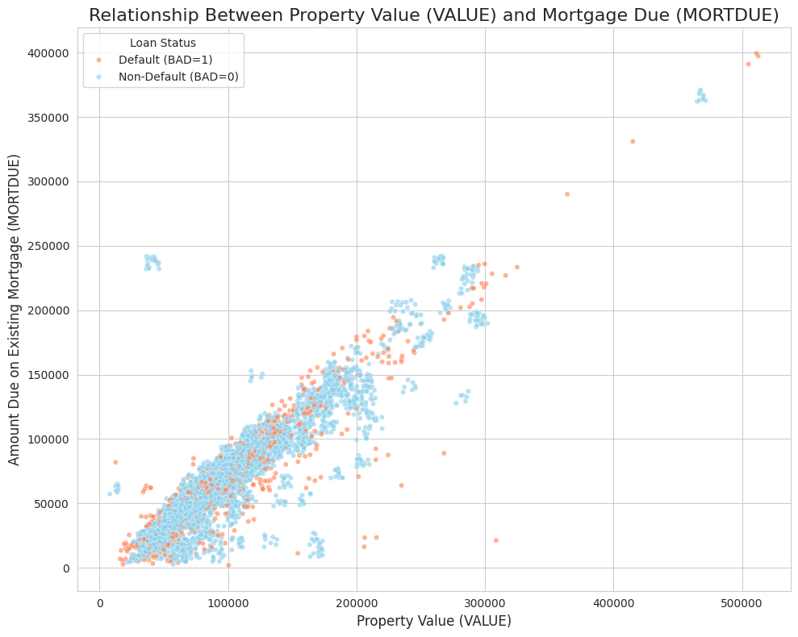

```
Scatter plot generated: mortdue_vs_value_scatter_plot.png
```

```python
# Set aesthetic style
sns.set_style("whitegrid")

# --- 1. Prepare Data ---
plot_data = df_Loan_original[['MORTDUE', 'VALUE', 'BAD']].copy()

# Drop rows where either MORTDUE or VALUE is missing
plot_data = plot_data.dropna()

# Rename BAD values for clear legend
plot_data['BAD_Status'] = plot_data['BAD'].map({
    0: 'Non-Default (BAD=0)',
    1: 'Default (BAD=1)'
})

# --- 2. Generate Scatter Plot (Pair Plot for two variables) ---
plt.figure(figsize=(10, 8))
scatter_plot = sns.scatterplot(
    x='VALUE',
    y='MORTDUE',
    hue='BAD_Status',
    data=plot_data,
    palette={'Non-Default (BAD=0)': 'skyblue', 'Default (BAD=1)': 'coral'},
    alpha=0.6,
    s=20 # Set size for better visual density
)

scatter_plot.set_title('Relationship Between Property Value (VALUE) and Mortgage Due (MORTDUE)', fontsize=16)
scatter_plot.set_xlabel('Property Value (VALUE)', fontsize=12)
scatter_plot.set_ylabel('Amount Due on Existing Mortgage (MORTDUE)', fontsize=12)
plt.legend(title='Loan Status')
plt.ticklabel_format(style='plain', axis='both', useOffset=False) # Prevent scientific notation
plt.tight_layout()
plt.show()

# Save the scatter plot
plt.savefig('mortdue_vs_value_scatter_plot.png')
plt.close()

print("Scatter plot generated: mortdue_vs_value_scatter_plot.png")
```

The scatter plot clearly visualizes the strong relationship between these two financial variables and offers insights into risk distribution:

a) The points cluster tightly along a diagonal line, visually confirming the high positive correlation noted in the heatmap. As the value of the property increases, the amount owed on the mortgage generally increases as well, which is an expected relationship in stable real estate markets.

b) Most of the Defaulters (coral points) are concentrated in the lower-left quadrant of the plot. This area represents properties with both lower overall VALUE and lower MORTDUE amounts (i.e., less expensive properties).

# **5.0 Analytical Approach**

## **5.1 Mention the alternative analytical approaches that you may see fit to be applied to the problem**

Based on findings so far from the preliminary data analysis, here are several alternative analytical approaches that can be applied to build a more robust and insightful model.

The initial analysis focused on linear correlations. Later a baseline Logistic Regression model will be generated to gain more understanding of the data. Since simple, Logistic Regression may miss complex, non-linear relationships in the data. Other models that will be used include:

a) Tree-Based Ensemble Models, including Random Forest, XGBoost, or LightGBM (Gradient Boosting Machines) will be used. These models inherently capture non-linear relationships and feature interactions without the need for extensive manual feature engineering. XGBoost/LightGBM are often the state-of-the-art for structured data and can significantly outperform Logistic Regression.

b) Deep Learning may also be considered. A simple Multi-Layer Perceptron (MLP) or a feed-forward neural network can learn intricate patterns and interactions. The small size of the dataset may however limit the use of this approach.

c) Since Loan defaults is typically a rare event, the dataset is likely imbalanced. Building a model on imbalanced data can lead to prediction of the majority class (no default) and performs poorly on identifying actual defaulters. SMOTE (Synthetic Minority Over-sampling Technique) or its variations (e.g., Borderline SMOTE) will be used to synthetically generate more samples of the minority class and ensure the data used to generate the model is balanced.

d) Multicollinearity between MORTDUE and VALUE was identified. To address this issue creating new features will be considered. Such an approach can significantly improve model performance. Principal Component Analysis (PCA) on the collinear features MORTDUE and VALUE will also be considered.

e) Regarding Encoding Categorical Features One-Hot encoding has been used to code the data. Target encoding will be considered where a category will be replaced with the mean of the target variable for that category, potentially capturing more predictive information. This requires careful cross-validation to prevent data leakage.